# 3Dマップによる地価の可視化

富山市の例

[岩田真一郎](https://shinichiro-iwata.github.io/)（[神奈川大学経済学部](https://www.econ.kanagawa-u.ac.jp/)）

2022-06-23作成，2022-06-27改訂

# 目的

[空間内挿による地価の可視化](https://shinichiro-iwata.github.io/geospatial-data-visualization/spatial-interpolation.html)で作成した地図を立体化．

ライブラリ：`sf`，`tidyverse`，`rayshader`

```r
library(sf)
library(tidyverse)

#3Dマップ作成のため
library(rayshader)
```

# 地価の立体化

[`rayshader`](https://www.rayshader.com/)パッケージはマッピングされた数値（`aes()`内の`fill`引数で指定された列）を立体的に表現する．

- ここでは，[空間内挿による地価の可視化](https://shinichiro-iwata.github.io/geospatial-data-visualization/spatial-interpolation.html)で作成した地図を3Dに変更．
  - 2D地図作成コードは[空間内挿による地価の可視化](https://shinichiro-iwata.github.io/geospatial-data-visualization/spatial-interpolation.html)参照．

**2022年の地図**

`ggplot()`で地図を作成し，名前を付ける（`map6`）．

- `plot_gg`は`ggplot()`で作成した地図を立体（3D）化．
  - [オプション](https://www.rayshader.com/reference/plot_gg.html)は大きさ，角度，ズーム調査など多岐にわたる．最低限必要なのが，`ggplot()`で作成した地図（`map6`），横幅（`width`，初期値は`3`），縦幅（`height`，初期値は`3`）の3つ．
- `render_snapshot()`で3Dマップを可視化．R Markdownに対応．

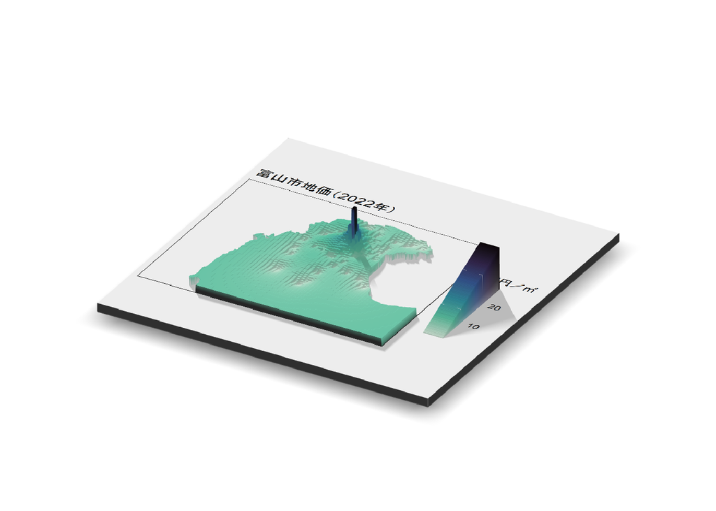

```r
#2022年の地図
map6<-
  ggplot()+
  geom_sf(data=Toyama_intersec6,
          aes(fill=var1.pred), color=NA)+
  scale_fill_viridis_c(option="G", direction=-1)+
  labs(fill="万円／㎡")+
  ggtitle("富山市地価（2022年）")+
  coord_sf(xlim= c(136.96, 137.4), ylim=c(36.5, 36.78),
           datum=NA)+
  theme_bw()

#3Dマップ作成
plot_gg(map6, width=4, height=4,
        windowsize=c(1400,866),
        zoom=0.6, phi=30, theta=30)

#可視化
render_snapshot()
```

**1997年，2007年，2022年の地図**

[空間内挿による地価の可視化](https://shinichiro-iwata.github.io/geospatial-data-visualization/spatial-interpolation.html)では，補論で空間内挿後（消費者物価調整済み）の3年分のデータを結合した．その地図を立体化．

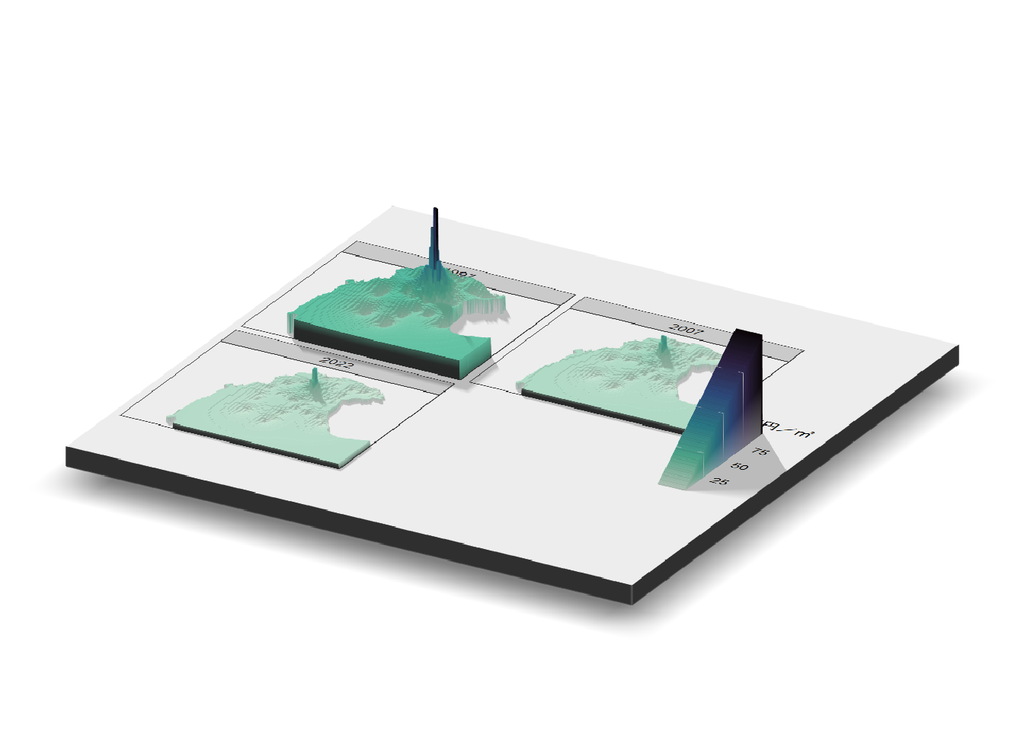

```r
#複数地図→1枚の地図
map75856<-
  ggplot()+geom_sf(data=Toyama_75856,
                 aes(fill=pred), color=NA)+
  scale_fill_viridis_c(option="G", direction=-1)+
  coord_sf(xlim=c(136.96, 137.4), ylim=c(36.5, 36.78),
           datum=NA)+
  facet_wrap(~year, ncol=2)+
  labs(fill="万円／㎡")+
  theme_bw()

#3Dマップの作成
plot_gg(map75856, multicore=TRUE,
        width=5, height=5, scale=250,
        windowsize=c(1400,866), zoom=0.5,
        phi=25, theta=30)

#可視化
render_snapshot()
```

**Rによる地理空間データの可視化**

- チュートリアル[ホーム](https://shinichiro-iwata.github.io/geospatial-data-visualization/)